# Hw2

Calvin Wong

2/16/2020

```r
library(forecast)
library(fpp2)
```

1. For the following series, find an appropriate Box-Cox transformation in order to stabilise the variance. usnetelec usgdp mcopper enplanements

```r
(lambda1 <- BoxCox.lambda(usnetelec))
```

```
## [1] 0.5167714
```

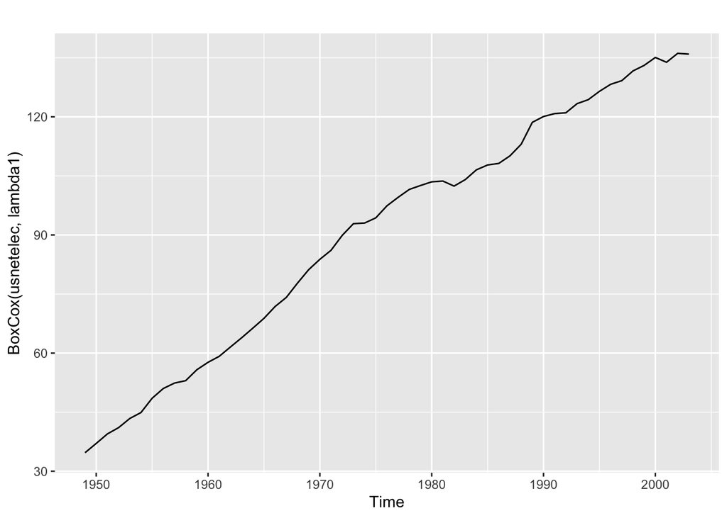

```r
autoplot(BoxCox(usnetelec,lambda1))
```

```r
(lambda2 <- BoxCox.lambda(usgdp))
```

```
## [1] 0.366352
```

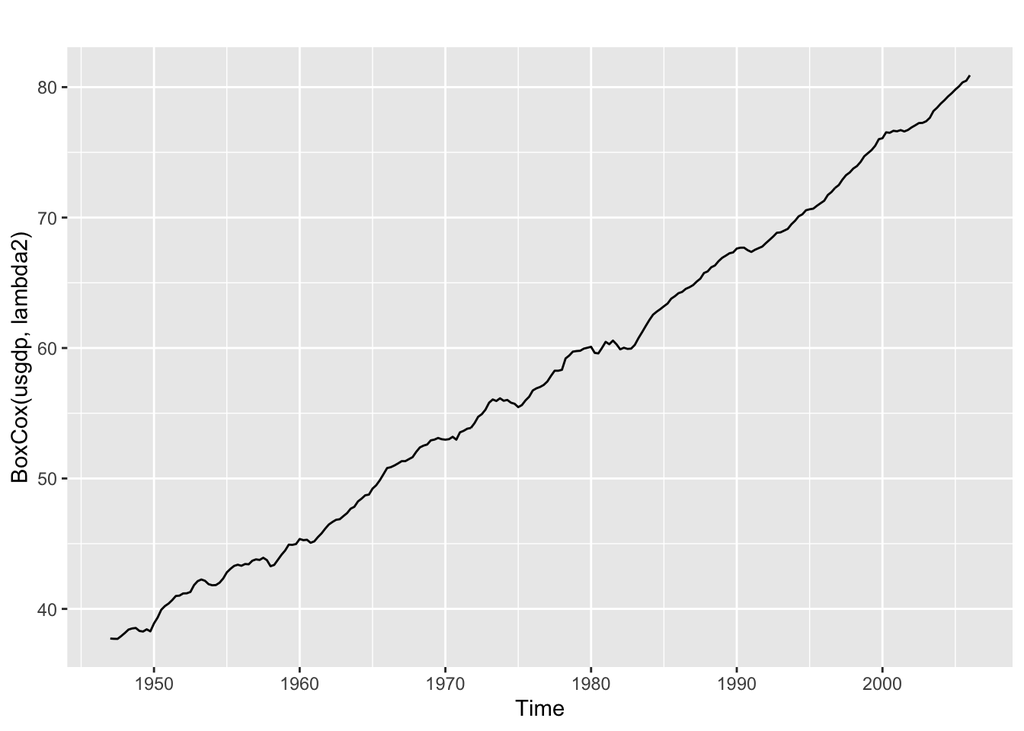

```r
autoplot(BoxCox(usgdp,lambda2))
```

```r
(lambda3 <- BoxCox.lambda(mcopper))
```

```
## [1] 0.1919047
```

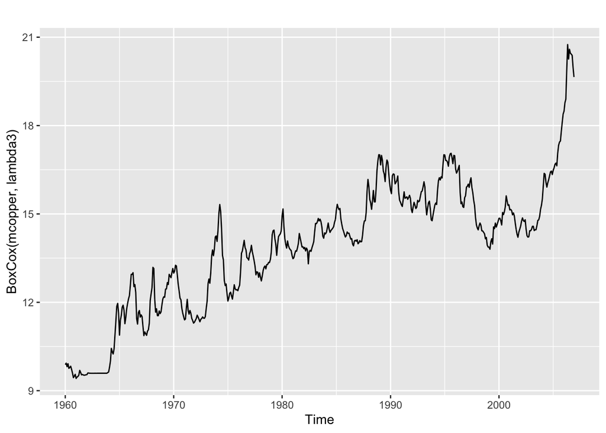

```r
autoplot(BoxCox(mcopper,lambda3))
```

```r
(lambda4 <- BoxCox.lambda(enplanements))
```

```
## [1] -0.2269461
```

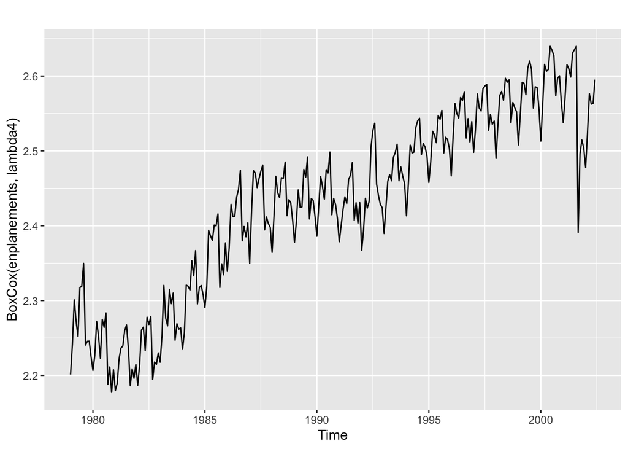

```r
autoplot(BoxCox(enplanements,lambda4))
```

2. Why is a Box-Cox transformation unhelpful for the cangas data?

The Box-Cox transformation is used to transform data into a normal distribution. However, in this instance, Box-Cox is unable to ‘smooth’ out excess seasonal variation, because of there isn’t a normal distribution. Therefore, the data looks exactly the same pre-transformation as post-transformation.

```r
(lambda5 <- BoxCox.lambda(cangas))
```

```
## [1] 0.5767759
```

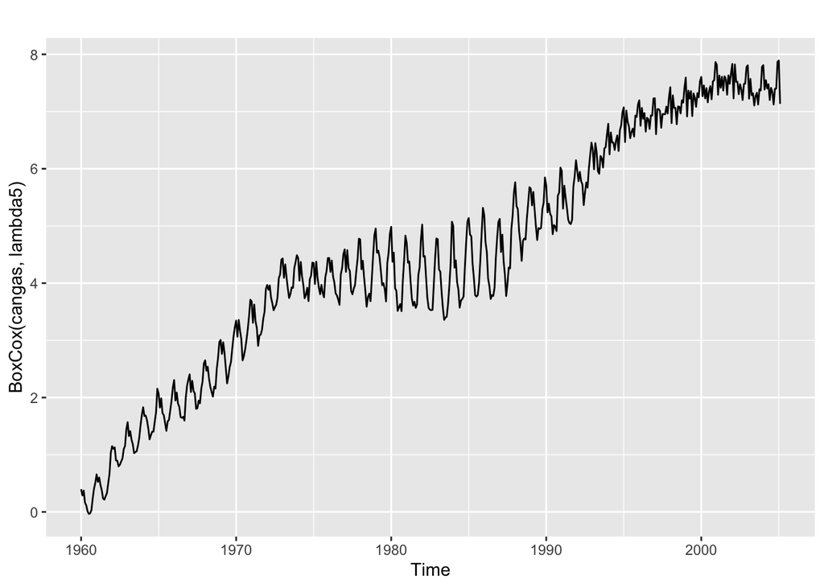

```r
autoplot(BoxCox(cangas,lambda5))
```

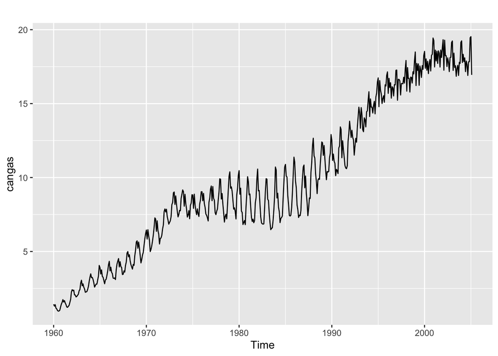

```r
autoplot(cangas)
```

3. What Box-Cox transformation would you select for your retail data (from Exercise 3 in Section 2.10)?

The BoxCox.lambda() function choosed a value of 0.452796 lambda.

```r
retaildata <- readxl::read_excel("retail.xlsx", skip=1)
myts <- ts(retaildata[,"A3349909T"],
  frequency=12, start=c(1982,4))
(lambda6 <- BoxCox.lambda(myts))
```

```
## [1] 0.452796
```

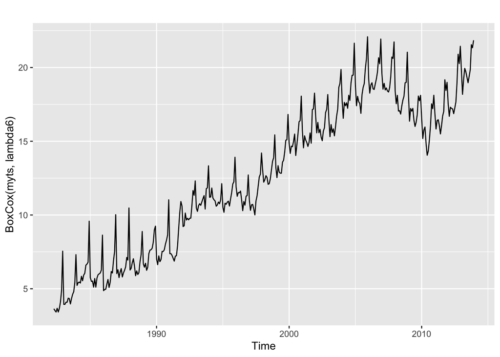

```r
autoplot(BoxCox(myts,lambda6))
```

8. For your retail time series (from Exercise 3 in Section 2.10):
1. Split the data into two parts using

```r
myts.train <- window(myts, end=c(2010,12))
myts.test <- window(myts, start=2011)
```

2. Check that your data have been split appropriately by producing the following plot.

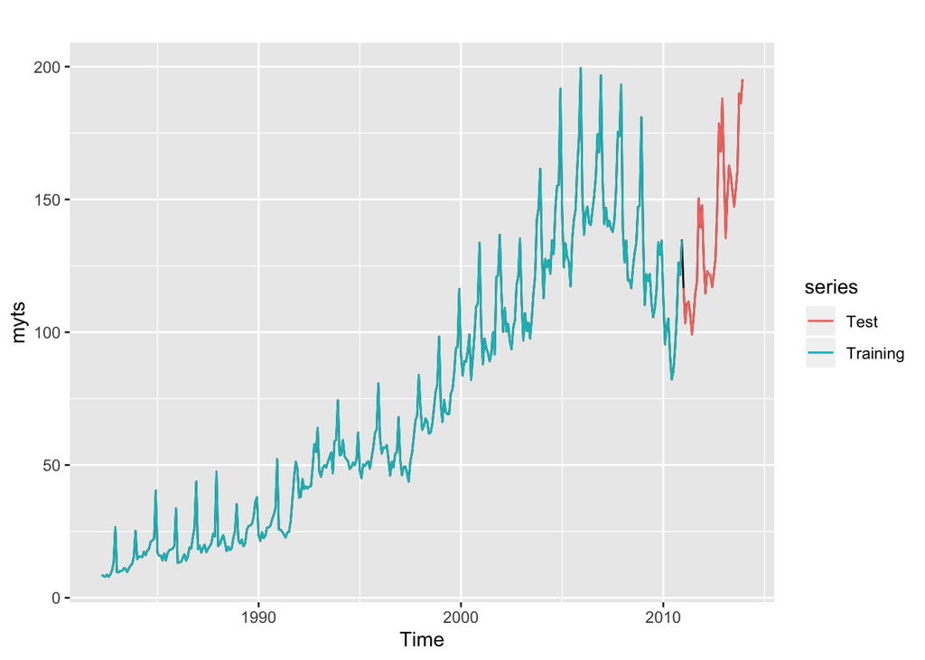

```r
autoplot(myts) +
  autolayer(myts.train, series="Training") +
  autolayer(myts.test, series="Test")
```

3. Calculate forecasts using snaive applied to myts.train.

```r
fc <- snaive(myts.train)
```

4. Compare the accuracy of your forecasts against the actual values stored in myts.test.

```r
accuracy(fc,myts.test)
```

```
##                     ME     RMSE       MAE       MPE     MAPE     MASE      ACF1
## Training set  3.388889 11.45467  8.768468  6.646756 13.88686 1.000000 0.8226344
## Test set     23.620833 27.48790 23.620833 17.658958 17.65896 2.693838 0.7694841
##              Theil's U
## Training set        NA
## Test set      2.051517
```

5. Check the residuals.

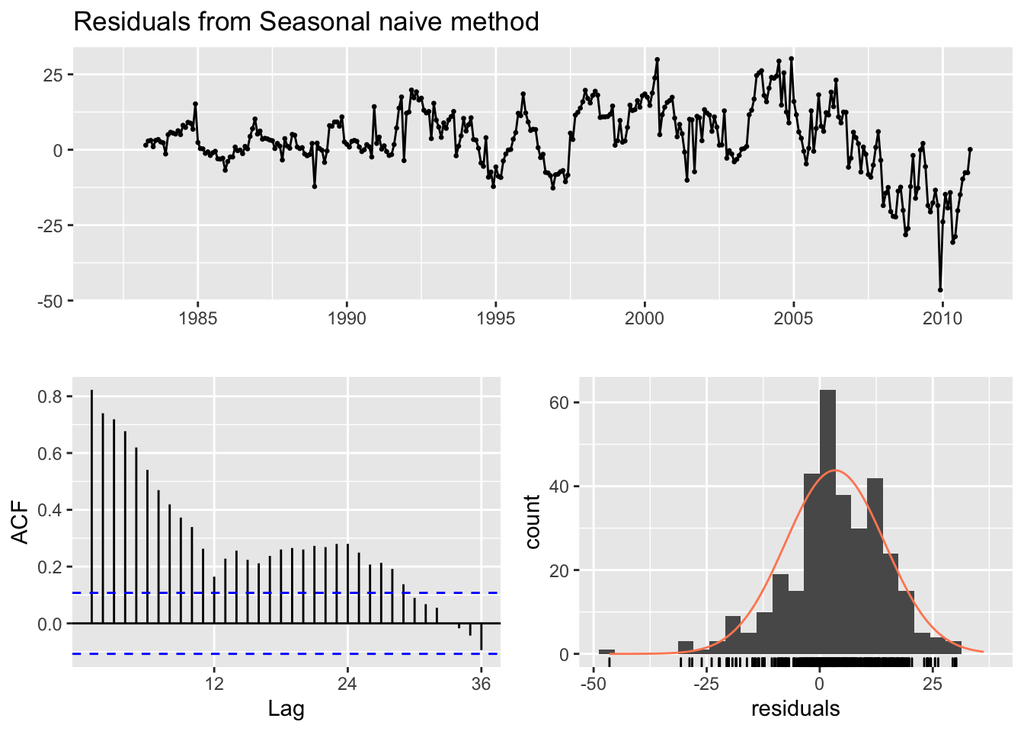

```
##
##  Ljung-Box test
##
## data:  Residuals from Seasonal naive method
## Q* = 1505.4, df = 24, p-value < 2.2e-16
##
## Model df: 0.   Total lags used: 24
```

```r
checkresiduals(fc)
```

Do the residuals appear to be uncorrelated and normally distributed?

6. How sensitive are the accuracy measures to the training/test split?